# Factors Lab - Key

Load all the libraries we will use in this lab.

```r
library(tidyverse)
```

### 1.0

Load the Youth Tobacco Survey data from http://jhudatascience.org/intro_to_r/data/Youth_Tobacco_Survey_YTS_Data.csv. `select` “Sample_Size”, “Education”, and “LocationAbbr”. Name this data “yts”.

```r
yts <- read_csv("http://jhudatascience.org/intro_to_r/data/Youth_Tobacco_Survey_YTS_Data.csv")
yts <- yts %>% select(Sample_Size, Education, LocationAbbr)
```

### 1.1

Create a boxplot showing the difference in “Sample_Size” between Middle School and High School “Education”. **Hint**: Use `aes(x = Education, y = Sample_Size)` and `geom_boxplot()`.

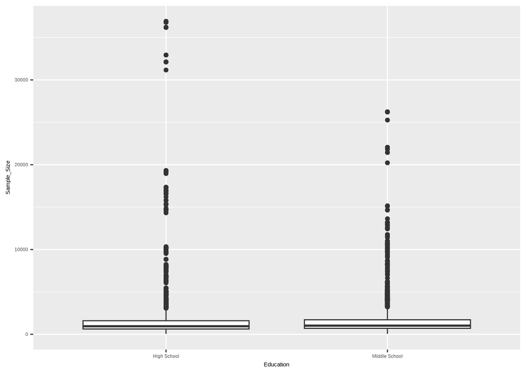

```r
yts %>%
  ggplot(aes(x = Education, y = Sample_Size)) +
  geom_boxplot()
```

### 1.2

Use `count` to count up the number of observations of data for each “Education” group.

```r
yts %>%
  count(Education)
```

```
## # A tibble: 2 × 2
##   Education         n
##   <chr>         <int>
## 1 High School    4588
## 2 Middle School  5206
```

### 1.3

Make “Education” a factor using the `mutate` and `factor` functions. Use the `levels` argument inside `factor` to reorder “Education”. Reorder this variable so that “Middle School” comes before “High School”. Assign the output the name “yts_fct”.

```r
yts_fct <-
  yts %>% mutate(Education = factor(Education,
    levels = c("Middle School", "High School")
  ))
```

### 1.4

Repeat question 1.1 and 1.2 using the “yts_fct” data. You should see different ordering in the plot and `count` table.

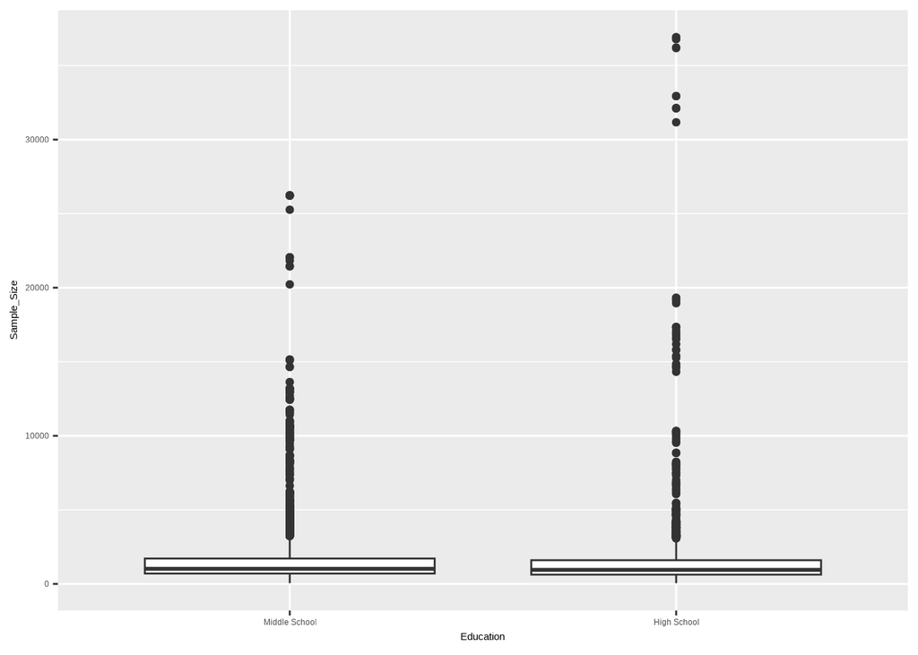

```r
yts_fct %>%
  ggplot(aes(x = Education, y = Sample_Size)) +
  geom_boxplot()
```

```r
yts_fct %>%
  count(Education)
```

```
## # A tibble: 2 × 2
##   Education         n
##   <fct>         <int>
## 1 Middle School  5206
## 2 High School    4588
```

# Practice on Your Own!

### P.1

Convert “LocationAbbr” (state) in “yts_fct” into a factor using the `mutate` and `factor` functions. Do not add a `levels =` argument.

```r
yts_fct <- yts_fct %>% mutate(LocationAbbr = factor(LocationAbbr))
```

### P.2

We want to create a new column that contains the group-level median sample size.

- Using the “yts_fct” data, `group_by` “LocationAbbr”.
- Then, use `mutate` to create a new column “med_sample_size” that is the median “Sample_Size”.
- **Hint**: Since you have already done `group_by`, a median “Sample_Size” will automatically be created for each unique level in “LocationAbbr”. Use the `median` function with `na.rm = TRUE`.

```r
yts_fct <- yts_fct %>%
  group_by(LocationAbbr) %>%
  mutate(med_sample_size = median(Sample_Size, na.rm = TRUE))
```

### P.3

We want to plot the “LocationAbbr” (state) by the “med_sample_size” column we created above. Using the `forcats` package, create a plot that:

- Has “LocationAbbr” on the x-axis
- Uses the `mapping` argument and the `fct_reorder` function to order the x-axis by “med_sample_size”
- Has “Sample_Size” on the y-axis
- Is a boxplot (`geom_boxplot`)
- Has the x axis label of `State` (Don’t worry if you get a warning about not being able to plot `NA` values.)

Save your plot using `ggsave()` with a width of 10 and height of 3.

```r
library(forcats)

yts_fct_plot <- yts_fct %>%
  drop_na() %>%
  ggplot(aes(
    x = fct_reorder(
      LocationAbbr, med_sample_size
    ),
    y = Sample_Size
  )) +
  geom_boxplot() +
  labs(x = "State")

ggsave(
  filename = "yts_fct.png", # will save in working directory
  plot = yts_fct_plot,
  width = 10, height = 3
)
```